# Midterm Project

Christopher Bussen

2024-03-15

```r
# load libraries
library(pacman)
pacman::p_load(tidyverse, DT, randomForest, corrplot, nnet, car, MASS, tree, class, e1071,
               gridExtra, rlang)
```

```r
# load dataset
ctg <- read_csv("/Users/christopherbussen/Documents/School/UDS2024/MTH415/midterm/CTG.csv")
# clean dataset
# get rid of first column (file name)
ctg <- ctg[, -1]

# according to original study, class only needed if you want to use for 10-class experiments
# DR not useful - all 0s
ctg <- subset(ctg, select = -c(DR, CLASS))
ctg$NSP <- as.factor(ctg$NSP)
```

**DATA CLEANING NOTE**: when first looking into this dataset, I looked at the website for the original study and it mentioned that the class variable is only needed if you want to conduct experiments for 10-class classification problems. As a result, I removed this variable from the dataset. I also dropped the first column of the dataset as it was simply the file name which will not help with classification as well as the variable DR as it was all 0s throughout the data.

## Introduction

In this report, I analyze a dataset related to fetal health based on many different predictors recorded from fetal cardiotocograms (CTGs). The goal of this report is to create a model that is able to give automated predictions of fetal health (variable NSP). The NSP variable has three classes: 1 (normal), 2 (suspect), and 3 (pathologic). As I have no prior experience with this kind of data or scenario, I do not have much of an idea of what variables should be important and what variables should not. Additionally, while I’m not sure how accurate predictions based on CTGs typically can be, I am hoping for a model that can achieve at least 90% accuracy.

## EDA

Below, I will perform some brief exploratory data analysis to get a better sense for the data and each variable, as well as the potential relationships between variables.

### Data Table

Below we can see the general structure of the dataset as a whole as well as the summary statistics tables for each variable. I also included the entire table of the dataset for full transparency. This helps us to understand the dataset more before creating models to try to predict NSP.

```r
# show structure and summary stats of dataset
str(ctg)
```

```
## tibble [2,126 × 22] (S3: tbl_df/tbl/data.frame)
##  $ LB      : num [1:2126] 120 132 133 134 132 134 134 122 122 122 ...
##  $ AC      : num [1:2126] 0 4 2 2 4 1 1 0 0 0 ...
##  $ FM      : num [1:2126] 0 0 0 0 0 0 0 0 0 0 ...
##  $ UC      : num [1:2126] 0 4 5 6 5 10 9 0 1 3 ...
##  $ ASTV    : num [1:2126] 73 17 16 16 16 26 29 83 84 86 ...
##  $ MSTV    : num [1:2126] 0.5 2.1 2.1 2.4 2.4 5.9 6.3 0.5 0.5 0.3 ...
##  $ ALTV    : num [1:2126] 43 0 0 0 0 0 0 6 5 6 ...
##  $ MLTV    : num [1:2126] 2.4 10.4 13.4 23 19.9 0 0 15.6 13.6 10.6 ...
##  $ DL      : num [1:2126] 0 2 2 2 0 9 6 0 0 0 ...
##  $ DS      : num [1:2126] 0 0 0 0 0 0 0 0 0 0 ...
##  $ DP      : num [1:2126] 0 0 0 0 0 2 2 0 0 0 ...
##  $ Width   : num [1:2126] 64 130 130 117 117 150 150 68 68 68 ...
##  $ Min     : num [1:2126] 62 68 68 53 53 50 50 62 62 62 ...
##  $ Max     : num [1:2126] 126 198 198 170 170 200 200 130 130 130 ...
##  $ Nmax    : num [1:2126] 2 6 5 11 9 5 6 0 0 1 ...
##  $ Nzeros  : num [1:2126] 0 1 1 0 0 3 3 0 0 0 ...
##  $ Mode    : num [1:2126] 120 141 141 137 137 76 71 122 122 122 ...
##  $ Mean    : num [1:2126] 137 136 135 134 136 107 107 122 122 122 ...
##  $ Median  : num [1:2126] 121 140 138 137 138 107 106 123 123 123 ...
##  $ Variance: num [1:2126] 73 12 13 13 11 170 215 3 3 1 ...
##  $ Tendency: num [1:2126] 1 0 0 1 1 0 0 1 1 1 ...
##  $ NSP     : Factor w/ 3 levels "1","2","3": 2 1 1 1 1 3 3 3 3 3 ...
```

```r
# summary stats
summary(ctg)
```

```
##        LB              AC               FM                UC
##  Min.   :106.0   Min.   : 0.000   Min.   :  0.000   Min.   : 0.00
##  1st Qu.:126.0   1st Qu.: 0.000   1st Qu.:  0.000   1st Qu.: 1.00
##  Median :133.0   Median : 1.000   Median :  0.000   Median : 3.00
##  Mean   :133.3   Mean   : 2.722   Mean   :  7.241   Mean   : 3.66
##  3rd Qu.:140.0   3rd Qu.: 4.000   3rd Qu.:  2.000   3rd Qu.: 5.00
##  Max.   :160.0   Max.   :26.000   Max.   :564.000   Max.   :23.00
##       ASTV            MSTV            ALTV             MLTV
##  Min.   :12.00   Min.   :0.200   Min.   : 0.000   Min.   : 0.000
##  1st Qu.:32.00   1st Qu.:0.700   1st Qu.: 0.000   1st Qu.: 4.600
##  Median :49.00   Median :1.200   Median : 0.000   Median : 7.400
##  Mean   :46.99   Mean   :1.333   Mean   : 9.847   Mean   : 8.188
##  3rd Qu.:61.00   3rd Qu.:1.700   3rd Qu.:11.000   3rd Qu.:10.800
##  Max.   :87.00   Max.   :7.000   Max.   :91.000   Max.   :50.700
##        DL              DS                 DP             Width
##  Min.   : 0.00   Min.   :0.000000   Min.   :0.0000   Min.   :  3.00
##  1st Qu.: 0.00   1st Qu.:0.000000   1st Qu.:0.0000   1st Qu.: 37.00
##  Median : 0.00   Median :0.000000   Median :0.0000   Median : 67.50
##  Mean   : 1.57   Mean   :0.003293   Mean   :0.1261   Mean   : 70.45
##  3rd Qu.: 3.00   3rd Qu.:0.000000   3rd Qu.:0.0000   3rd Qu.:100.00
##  Max.   :16.00   Max.   :1.000000   Max.   :4.0000   Max.   :180.00
##       Min              Max           Nmax            Nzeros
##  Min.   : 50.00   Min.   :122   Min.   : 0.000   Min.   : 0.0000
##  1st Qu.: 67.00   1st Qu.:152   1st Qu.: 2.000   1st Qu.: 0.0000
##  Median : 93.00   Median :162   Median : 3.000   Median : 0.0000
##  Mean   : 93.58   Mean   :164   Mean   : 4.068   Mean   : 0.3236
##  3rd Qu.:120.00   3rd Qu.:174   3rd Qu.: 6.000   3rd Qu.: 0.0000
##  Max.   :159.00   Max.   :238   Max.   :18.000   Max.   :10.0000
##       Mode            Mean           Median         Variance
##  Min.   : 60.0   Min.   : 73.0   Min.   : 77.0   Min.   :  0.00
##  1st Qu.:129.0   1st Qu.:125.0   1st Qu.:129.0   1st Qu.:  2.00
##  Median :139.0   Median :136.0   Median :139.0   Median :  7.00
##  Mean   :137.5   Mean   :134.6   Mean   :138.1   Mean   : 18.81
##  3rd Qu.:148.0   3rd Qu.:145.0   3rd Qu.:148.0   3rd Qu.: 24.00
##  Max.   :187.0   Max.   :182.0   Max.   :186.0   Max.   :269.00
##     Tendency       NSP
##  Min.   :-1.0000   1:1655
##  1st Qu.: 0.0000   2: 295
##  Median : 0.0000   3: 176
##  Mean   : 0.3203
##  3rd Qu.: 1.0000
##  Max.   : 1.0000
```

```r
# show table
DT::datatable(ctg)
```

|  | LB | AC | FM | UC | ASTV | MSTV | ALTV | MLTV | DL | DS | DP | Width | Min | Max | Nmax | Nzeros | Mode | Mean | Median | Variance | Tendency | NSP |
| --- | --- | --- | --- | --- | --- | --- | --- | --- | --- | --- | --- | --- | --- | --- | --- | --- | --- | --- | --- | --- | --- | --- |
| 1 | 120 | 0 | 0 | 0 | 73 | 0.5 | 43 | 2.4 | 0 | 0 | 0 | 64 | 62 | 126 | 2 | 0 | 120 | 137 | 121 | 73 | 1 | 2 |
| 2 | 132 | 4 | 0 | 4 | 17 | 2.1 | 0 | 10.4 | 2 | 0 | 0 | 130 | 68 | 198 | 6 | 1 | 141 | 136 | 140 | 12 | 0 | 1 |
| 3 | 133 | 2 | 0 | 5 | 16 | 2.1 | 0 | 13.4 | 2 | 0 | 0 | 130 | 68 | 198 | 5 | 1 | 141 | 135 | 138 | 13 | 0 | 1 |
| 4 | 134 | 2 | 0 | 6 | 16 | 2.4 | 0 | 23 | 2 | 0 | 0 | 117 | 53 | 170 | 11 | 0 | 137 | 134 | 137 | 13 | 1 | 1 |
| 5 | 132 | 4 | 0 | 5 | 16 | 2.4 | 0 | 19.9 | 0 | 0 | 0 | 117 | 53 | 170 | 9 | 0 | 137 | 136 | 138 | 11 | 1 | 1 |
| 6 | 134 | 1 | 0 | 10 | 26 | 5.9 | 0 | 0 | 9 | 0 | 2 | 150 | 50 | 200 | 5 | 3 | 76 | 107 | 107 | 170 | 0 | 3 |
| 7 | 134 | 1 | 0 | 9 | 29 | 6.3 | 0 | 0 | 6 | 0 | 2 | 150 | 50 | 200 | 6 | 3 | 71 | 107 | 106 | 215 | 0 | 3 |
| 8 | 122 | 0 | 0 | 0 | 83 | 0.5 | 6 | 15.6 | 0 | 0 | 0 | 68 | 62 | 130 | 0 | 0 | 122 | 122 | 123 | 3 | 1 | 3 |
| 9 | 122 | 0 | 0 | 1 | 84 | 0.5 | 5 | 13.6 | 0 | 0 | 0 | 68 | 62 | 130 | 0 | 0 | 122 | 122 | 123 | 3 | 1 | 3 |
| 10 | 122 | 0 | 0 | 3 | 86 | 0.3 | 6 | 10.6 | 0 | 0 | 0 | 68 | 62 | 130 | 1 | 0 | 122 | 122 | 123 | 1 | 1 | 3 |

[output cut: 2116 more lines]

```r
# look at distribution of classes
(nsp_tab <- table(ctg$NSP))
```

```
##
##    1    2    3
## 1655  295  176
```

```r
# class n summary
n.class <- filter(ctg, NSP == 1)
summary(n.class)
```

```
##        LB            AC               FM                UC
##  Min.   :106   Min.   : 0.000   Min.   :  0.000   Min.   : 0.000
##  1st Qu.:125   1st Qu.: 0.000   1st Qu.:  0.000   1st Qu.: 2.000
##  Median :132   Median : 2.000   Median :  0.000   Median : 4.000
##  Mean   :132   Mean   : 3.424   Mean   :  6.371   Mean   : 3.984
##  3rd Qu.:138   3rd Qu.: 5.000   3rd Qu.:  2.000   3rd Qu.: 6.000
##  Max.   :160   Max.   :26.000   Max.   :564.000   Max.   :17.000
##       ASTV            MSTV            ALTV             MLTV
##  Min.   :12.00   Min.   :0.200   Min.   : 0.000   Min.   : 0.000
##  1st Qu.:29.00   1st Qu.:0.800   1st Qu.: 0.000   1st Qu.: 4.850
##  Median :41.00   Median :1.300   Median : 0.000   Median : 8.000
##  Mean   :42.47   Mean   :1.431   Mean   : 5.045   Mean   : 8.706
##  3rd Qu.:56.00   3rd Qu.:1.750   3rd Qu.: 4.000   3rd Qu.:11.500
##  Max.   :83.00   Max.   :7.000   Max.   :73.000   Max.   :50.700
##        DL              DS                  DP              Width
##  Min.   : 0.00   Min.   :0.0000000   Min.   :0.00000   Min.   : 10.0
##  1st Qu.: 0.00   1st Qu.:0.0000000   1st Qu.:0.00000   1st Qu.: 42.0
##  Median : 0.00   Median :0.0000000   Median :0.00000   Median : 71.0
##  Mean   : 1.61   Mean   :0.0006042   Mean   :0.04169   Mean   : 73.4
##  3rd Qu.: 3.00   3rd Qu.:0.0000000   3rd Qu.:0.00000   3rd Qu.:100.0
##  Max.   :14.00   Max.   :1.0000000   Max.   :1.00000   Max.   :176.0
##       Min              Max             Nmax            Nzeros
##  Min.   : 50.00   Min.   :122.0   Min.   : 0.000   Min.   : 0.0000
##  1st Qu.: 67.00   1st Qu.:152.0   1st Qu.: 2.000   1st Qu.: 0.0000
##  Median : 90.00   Median :163.0   Median : 4.000   Median : 0.0000
##  Mean   : 91.09   Mean   :164.5   Mean   : 4.163   Mean   : 0.3353
##  3rd Qu.:114.00   3rd Qu.:175.0   3rd Qu.: 6.000   3rd Qu.: 0.0000
##  Max.   :159.00   Max.   :238.0   Max.   :18.000   Max.   :10.0000
##       Mode            Mean           Median         Variance
##  Min.   : 86.0   Min.   : 88.0   Min.   :105.0   Min.   :  0.00
##  1st Qu.:129.0   1st Qu.:125.0   1st Qu.:129.0   1st Qu.:  3.00
##  Median :138.0   Median :135.0   Median :138.0   Median :  9.00
##  Mean   :138.3   Mean   :135.1   Mean   :138.5   Mean   : 17.48
##  3rd Qu.:147.0   3rd Qu.:144.0   3rd Qu.:147.0   3rd Qu.: 24.00
##  Max.   :187.0   Max.   :182.0   Max.   :186.0   Max.   :177.00
##     Tendency      NSP
##  Min.   :-1.000   1:1655
##  1st Qu.: 0.000   2:   0
##  Median : 0.000   3:   0
##  Mean   : 0.342
##  3rd Qu.: 1.000
##  Max.   : 1.000
```

```r
# class s summary
s.class <- filter(ctg, NSP == 2)
summary(s.class)
```

```
##        LB              AC               FM                UC
##  Min.   :120.0   Min.   :0.0000   Min.   :  0.000   Min.   : 0.000
##  1st Qu.:137.0   1st Qu.:0.0000   1st Qu.:  0.000   1st Qu.: 0.000
##  Median :143.0   Median :0.0000   Median :  0.000   Median : 1.000
##  Mean   :141.7   Mean   :0.2136   Mean   :  7.088   Mean   : 2.078
##  3rd Qu.:147.0   3rd Qu.:0.0000   3rd Qu.:  3.000   3rd Qu.: 3.000
##  Max.   :159.0   Max.   :6.0000   Max.   :489.000   Max.   :23.000
##       ASTV           MSTV            ALTV            MLTV
##  Min.   :18.0   Min.   :0.200   Min.   : 0.00   Min.   : 0.000
##  1st Qu.:58.0   1st Qu.:0.400   1st Qu.:11.00   1st Qu.: 5.600
##  Median :63.0   Median :0.400   Median :27.00   Median : 7.100
##  Mean   :61.9   Mean   :0.639   Mean   :29.03   Mean   : 8.026
##  3rd Qu.:69.5   3rd Qu.:0.600   3rd Qu.:45.00   3rd Qu.: 9.800
##  Max.   :79.0   Max.   :6.300   Max.   :68.00   Max.   :29.500
##        DL                DS          DP              Width
##  Min.   : 0.0000   Min.   :0   Min.   :0.00000   Min.   :  8.00
##  1st Qu.: 0.0000   1st Qu.:0   1st Qu.:0.00000   1st Qu.: 20.00
##  Median : 0.0000   Median :0   Median :0.00000   Median : 31.00
##  Mean   : 0.4034   Mean   :0   Mean   :0.06441   Mean   : 49.16
##  3rd Qu.: 0.0000   3rd Qu.:0   3rd Qu.:0.00000   3rd Qu.: 73.00
##  Max.   :10.0000   Max.   :0   Max.   :3.00000   Max.   :150.00
##       Min             Max             Nmax            Nzeros
##  Min.   : 50.0   Min.   :126.0   Min.   : 0.000   Min.   :0.0000
##  1st Qu.: 84.0   1st Qu.:152.0   1st Qu.: 1.000   1st Qu.:0.0000
##  Median :127.0   Median :159.0   Median : 2.000   Median :0.0000
##  Mean   :113.3   Mean   :162.5   Mean   : 3.312   Mean   :0.2441
##  3rd Qu.:136.0   3rd Qu.:169.0   3rd Qu.: 4.000   3rd Qu.:0.0000
##  Max.   :155.0   Max.   :200.0   Max.   :16.000   Max.   :8.0000
##       Mode            Mean           Median         Variance
##  Min.   : 90.0   Min.   : 98.0   Min.   : 91.0   Min.   :  0.000
##  1st Qu.:142.0   1st Qu.:140.0   1st Qu.:142.0   1st Qu.:  0.000
##  Median :147.0   Median :146.0   Median :148.0   Median :  1.000
##  Mean   :146.6   Mean   :144.8   Mean   :147.1   Mean   :  7.214
##  3rd Qu.:154.0   3rd Qu.:152.0   3rd Qu.:155.0   3rd Qu.:  4.000
##  Max.   :167.0   Max.   :172.0   Max.   :174.0   Max.   :116.000
##     Tendency       NSP
##  Min.   :-1.0000   1:  0
##  1st Qu.: 0.0000   2:295
##  Median : 0.0000   3:  0
##  Mean   : 0.4339
##  3rd Qu.: 1.0000
##  Max.   : 1.0000
```

```r
# class p summary
p.class <- filter(ctg, NSP == 3)
summary(p.class)
```

```
##        LB              AC               FM               UC
##  Min.   :110.0   Min.   :0.0000   Min.   :  0.00   Min.   : 0.000
##  1st Qu.:128.0   1st Qu.:0.0000   1st Qu.:  0.00   1st Qu.: 0.000
##  Median :132.0   Median :0.0000   Median :  1.00   Median : 2.500
##  Mean   :131.7   Mean   :0.3295   Mean   : 15.68   Mean   : 3.261
##  3rd Qu.:134.0   3rd Qu.:0.0000   3rd Qu.:  2.00   3rd Qu.: 5.000
##  Max.   :152.0   Max.   :4.0000   Max.   :443.00   Max.   :14.000
##       ASTV            MSTV            ALTV            MLTV
##  Min.   :18.00   Min.   :0.200   Min.   : 0.00   Min.   : 0.000
##  1st Qu.:61.00   1st Qu.:0.300   1st Qu.: 0.00   1st Qu.: 0.000
##  Median :65.00   Median :1.700   Median : 0.00   Median : 3.250
##  Mean   :64.54   Mean   :1.576   Mean   :22.85   Mean   : 3.589
##  3rd Qu.:73.25   3rd Qu.:2.500   3rd Qu.:64.75   3rd Qu.: 5.800
##  Max.   :87.00   Max.   :6.300   Max.   :91.00   Max.   :21.500
##        DL               DS                DP            Width
##  Min.   : 0.000   Min.   :0.00000   Min.   :0.000   Min.   :  3.00
##  1st Qu.: 0.000   1st Qu.:0.00000   1st Qu.:0.000   1st Qu.: 23.00
##  Median : 2.000   Median :0.00000   Median :1.000   Median : 92.50
##  Mean   : 3.153   Mean   :0.03409   Mean   :1.023   Mean   : 78.35
##  3rd Qu.: 6.000   3rd Qu.:0.00000   3rd Qu.:2.000   3rd Qu.:116.50
##  Max.   :16.000   Max.   :1.00000   Max.   :4.000   Max.   :180.00
##       Min              Max             Nmax            Nzeros
##  Min.   : 50.00   Min.   :128.0   Min.   : 0.000   Min.   :0.0000
##  1st Qu.: 55.75   1st Qu.:146.0   1st Qu.: 1.000   1st Qu.:0.0000
##  Median : 66.00   Median :158.5   Median : 4.000   Median :0.0000
##  Mean   : 83.98   Mean   :162.3   Mean   : 4.443   Mean   :0.3466
##  3rd Qu.:123.25   3rd Qu.:177.8   3rd Qu.: 7.000   3rd Qu.:0.2500
##  Max.   :154.00   Max.   :230.0   Max.   :14.000   Max.   :3.0000
##       Mode            Mean            Median         Variance
##  Min.   : 60.0   Min.   : 73.00   Min.   : 77.0   Min.   :  0.00
##  1st Qu.: 91.0   1st Qu.: 95.75   1st Qu.:106.0   1st Qu.:  1.00
##  Median :122.5   Median :106.50   Median :116.0   Median : 36.50
##  Mean   :114.6   Mean   :112.98   Mean   :119.6   Mean   : 50.73
##  3rd Qu.:135.0   3rd Qu.:134.00   3rd Qu.:135.0   3rd Qu.: 80.00
##  Max.   :160.0   Max.   :158.00   Max.   :160.0   Max.   :269.00
##     Tendency        NSP
##  Min.   :-1.00000   1:  0
##  1st Qu.:-1.00000   2:  0
##  Median : 0.00000   3:176
##  Mean   :-0.07386
##  3rd Qu.: 0.00000
##  Max.   : 1.00000
```

From the table of NSP class values, we see there are clearly more (1655) observations of class Normal (NSP=1) than both Suspect (NSP=2) or Pathologic (NSP=3), which we would expect. Next, there are 295 observations of class S and only 176 of class P. I also included the summary statistics for each variable among observations for each value of NSP.

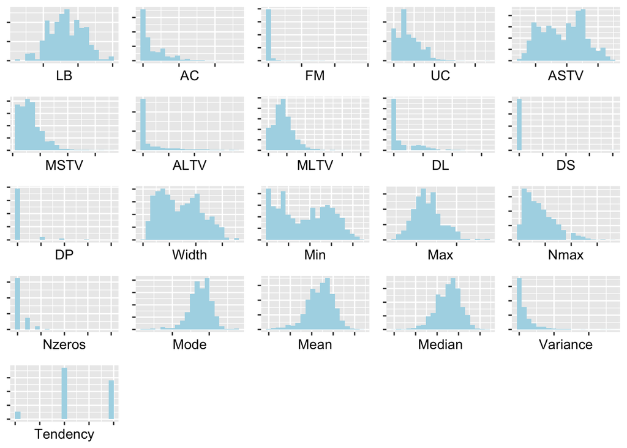

```r
plots <- list()
feature_names <- names(ctg[, sapply(ctg, is.numeric)])

for (i in seq_along(feature_names)) {
    feature <- feature_names[i]
    plots[[i]] <- ggplot(ctg, aes(!!sym(feature))) +
                  geom_histogram(bins = 20, fill = "lightblue") +
                  theme(axis.title.y = element_blank(), axis.text = element_blank())
}

do.call("grid.arrange", c(plots, ncol = 5))
```

Above I decided to plot histograms of each of the 21 features to visualize their overall distribution in order to give more context to the summary statistics provided above. From these histograms, it is easier to see their general shape, spread, and measure of center in addition to any potential unusual features. For example, we can see that several of the variables appear to be roughly symmetric (LB, Max, Mean, Median) whereas several others are rather skewed or only have a few different values.

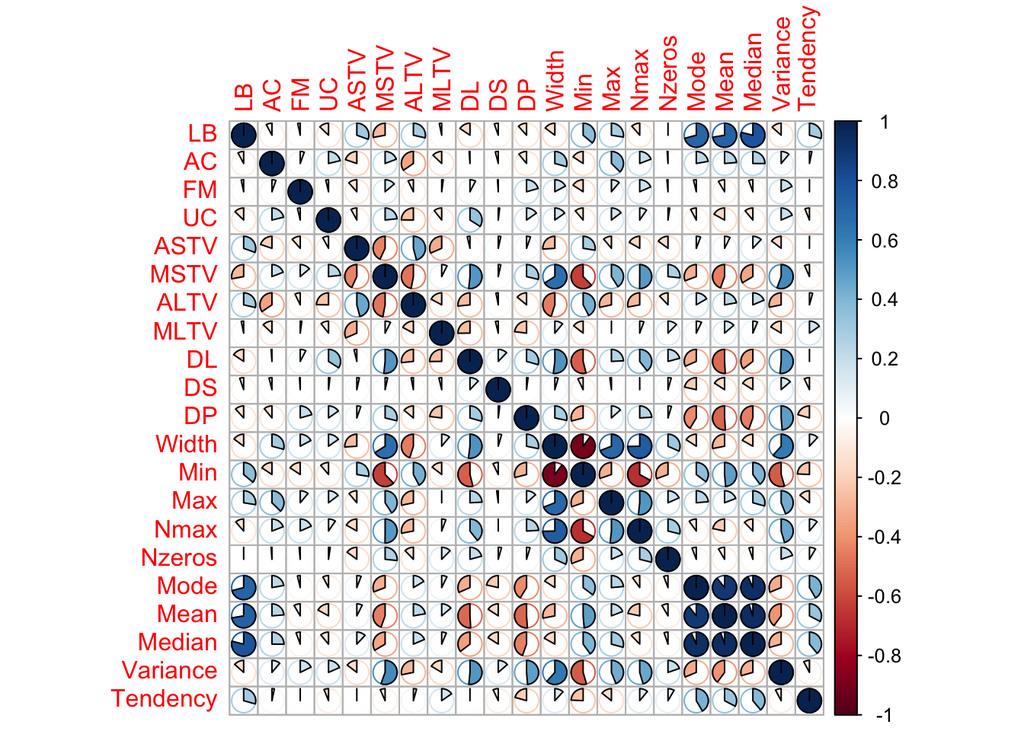

```r
# look at how certain features are related to each other
# correlation plot between variables
cor_mat <- cor(ctg[sapply(ctg, is.numeric)])
corrplot(cor_mat, method = "pie")
```

This correlation plot shows as the strength and direction of the relationships between each of the 21 predictors in this dataset. As we can see here, some of the variables that tend to be more correlated with each other are “LB”, “MSTV”, “Min”, “Nmax”, “Mean”, “Median”, “Mode”, “Width”, and “Variance”. Below I will plot these variables against each other while using different colors to show classes.

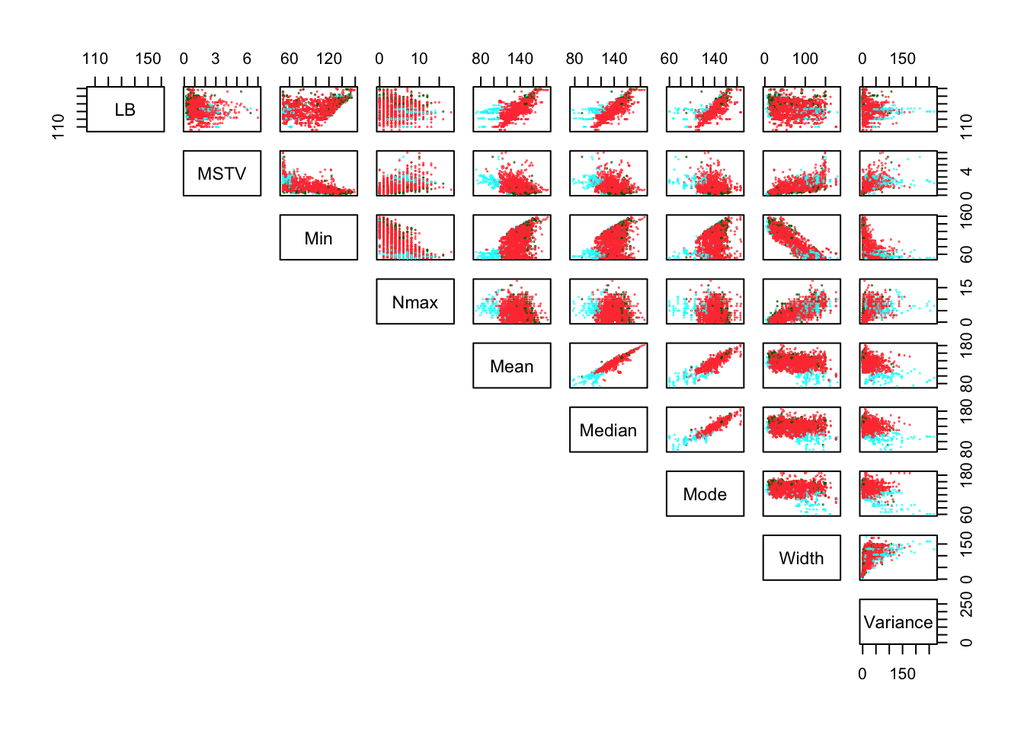

```r
# create scatterplots of some of the more correlated variables
top_corr <- c("LB","MSTV","Min","Nmax","Mean","Median","Mode","Width", "Variance")
colors <- c("brown1", "darkgreen", "cyan")
pairs(ctg[, top_corr], pch = 1, lower.panel = NULL, cex = 0.1, col = colors[ctg$NSP])
```

## Models

In this section, I will create several models that attempt to accurately predict the values of NSP for each of the observations in the testing data. Because NSP has three classes, I must ensure that each model allows for more than just binary classification. For example, I cannot use logistic regression but instead would have to use multinomial regression. The algorithms I plan to use include multinomial regression, decision trees, random forests, K-Nearest Neighbors (KNN), and Support Vector Machine (SVM). Throughout model creation, (when applicable) I used cross-validation to tune my parameters and/or used for loops to test a set of values for a given tuning parameter and picked the value that minimized error. Lastly, in an attempts to avoid overfitting, I used cross-validation to ensure that there were no major variations and I made sure that my models worked well for both training and testing data instead of dropping off for the test data. As you’ll see further below, I also used examples of much more simple models through dimensionality reduction using PCA.

```r
# create train and test data
set.seed(22)
trainIndex <- sample(c(1:nrow(ctg)), 1750)

train <- ctg[trainIndex, ]
test <- ctg[-trainIndex, ]
```

### Multinomial Regression Models

Below I will create a multinomial regression model using the full set of predictors as well as a model with a reduced set of predictors found through backwards elimination.

```r
fit.multi = multinom(NSP ~ ., data = train)
summary(fit.multi)
```

```
## Call:
## multinom(formula = NSP ~ ., data = train)
##
## Coefficients:
##   (Intercept)          LB        AC         FM         UC      ASTV       MSTV
## 2   -18.13917 -0.07142609 -1.214431 0.01232451 -0.1959401 0.0872997 -0.4912526
## 3   -21.81175  0.23328857 -1.486992 0.02367742 -0.4270141 0.1897863 -1.2119755
##         ALTV        MLTV          DL        DS       DP      Width        Min
## 2 0.02638585 0.006835643 -0.07808215 0.9533553 3.364587 0.01103156 0.01880336
## 3 0.08582668 0.110125123  0.01185531 6.8141106 4.433203 0.02706212 0.02971511
##          Max       Nmax     Nzeros        Mode       Mean      Median
## 2 0.02983492  0.1315872 -0.1212119 -0.06365406  0.2242137 -0.05377622
## 3 0.05677723 -0.5690398  0.6047977 -0.05583491 -0.0777794 -0.14965479
##     Variance  Tendency
## 2 0.03065976 0.4655070
## 3 0.07239239 0.5668411
##
## Std. Errors:
##   (Intercept)         LB        AC          FM        UC       ASTV      MSTV
## 2   1.8588163 0.03347473 0.1674886 0.002727899 0.0467596 0.01116247 0.2982123
## 3   0.4043623 0.05618017 0.3679676 0.004966951 0.1009539 0.02278281 0.4185884
##          ALTV       MLTV        DL           DS        DP       Width
## 2 0.006674876 0.03647868 0.1265421 0.0001147661 0.6278151 0.004585668
## 3 0.011213228 0.06622332 0.1373080 0.0001290915 0.6426810 0.007853348
##           Min        Max       Nmax    Nzeros       Mode       Mean     Median
## 2 0.008193782 0.01062848 0.05992209 0.1693085 0.02700815 0.06560109 0.06631642
## 3 0.012397171 0.01520685 0.15775581 0.3484942 0.04006408 0.04981937 0.06719573
##      Variance  Tendency
## 2 0.008459306 0.2836045
## 3 0.011864052 0.4653092
##
## Residual Deviance: 765.3782
## AIC: 849.3782
```

```r
preds <- predict(fit.multi, newdata = test)
# print confusion matrix
(confusion_matrix <- table(Predicted = preds, Actual = test$NSP))
```

```
##          Actual
## Predicted   1   2   3
##         1 270  20   2
##         2  13  31   2
##         3   2   6  30
```

```r
# Calculate accuracy
(accuracy <- sum(diag(confusion_matrix)) / sum(confusion_matrix))
```

```
## [1] 0.8803191
```

```r
# code to find p-values below: insignificant predictors to be removed below
# Get coefficients and standard errors
# coefs <- coefficients(fit.multi)
# std_errors <- summary(fit.multi)$standard.errors

# Calculate z-values
# z_values <- coefs / std_errors

# Calculate p-values
# (p_values <- 2 * (1 - pnorm(abs(z_values))))
```

Here we see that the full multinomial regression model performs well with an accuracy of 88%. While this is solid for our first model, it can likely be improved upon by reducing the high dimensionality.

```r
# perform feature selection using backward elimination - backward less prone to overfitting
# put in own code block and set message=FALSE because output was very long
backward.elim <- stepAIC(fit.multi, direction = "backward", trace = FALSE)
```

```r
summary(backward.elim)
```

```
## Call:
## multinom(formula = NSP ~ LB + AC + FM + UC + ASTV + MSTV + ALTV +
##     DP + Width + Min + Nmax + Mode + Mean + Variance, data = train)
##
## Coefficients:
##   (Intercept)          LB        AC         FM         UC       ASTV       MSTV
## 2   -17.61735 -0.09797353 -1.252867 0.01194858 -0.1976294 0.08724616 -0.5620698
## 3   -17.84826  0.14756447 -1.880594 0.02266634 -0.4296163 0.17580977 -1.1451392
##         ALTV       DP      Width        Min       Nmax        Mode        Mean
## 2 0.02568097 3.687662 0.02758704 0.02740720  0.1318702 -0.07744844  0.22872229
## 3 0.07595129 4.645933 0.07406065 0.05818348 -0.5898684 -0.10337912 -0.08134664
##     Variance
## 2 0.02891755
## 3 0.07121481
##
## Std. Errors:
##   (Intercept)         LB        AC          FM         UC       ASTV      MSTV
## 2   1.7794341 0.03043602 0.1670433 0.002679272 0.04490590 0.01102348 0.2962107
## 3   0.4524687 0.04346843 0.3165653 0.005083575 0.09494592 0.02093410 0.4058310
##          ALTV        DP      Width        Min       Nmax       Mode       Mean
## 2 0.006112719 0.6098590 0.01115230 0.01289700 0.05814235 0.02464039 0.03607993
## 3 0.010260779 0.6166001 0.01508301 0.01786982 0.14581472 0.02618779 0.03799019
##      Variance
## 2 0.008322288
## 3 0.011162245
##
## Residual Deviance: 779.3428
## AIC: 839.3428
```

```r
# create new reduced model w call from backward elim
fit.multi.reduced <- multinom(formula = NSP ~ LB + AC + FM + UC + ASTV + MSTV + ALTV +
    DP + Width + Min + Nmax + Mode + Mean + Variance, data = train)
summary(fit.multi.reduced)
```

```
## Call:
## multinom(formula = NSP ~ LB + AC + FM + UC + ASTV + MSTV + ALTV +
##     DP + Width + Min + Nmax + Mode + Mean + Variance, data = train)
##
## Coefficients:
##   (Intercept)          LB        AC         FM         UC       ASTV       MSTV
## 2   -17.61735 -0.09797353 -1.252867 0.01194858 -0.1976294 0.08724616 -0.5620698
## 3   -17.84826  0.14756447 -1.880594 0.02266634 -0.4296163 0.17580977 -1.1451392
##         ALTV       DP      Width        Min       Nmax        Mode        Mean
## 2 0.02568097 3.687662 0.02758704 0.02740720  0.1318702 -0.07744844  0.22872229
## 3 0.07595129 4.645933 0.07406065 0.05818348 -0.5898684 -0.10337912 -0.08134664
##     Variance
## 2 0.02891755
## 3 0.07121481
##
## Std. Errors:
##   (Intercept)         LB        AC          FM         UC       ASTV      MSTV
## 2   1.7794341 0.03043602 0.1670433 0.002679272 0.04490590 0.01102348 0.2962107
## 3   0.4524687 0.04346843 0.3165653 0.005083575 0.09494592 0.02093410 0.4058310
##          ALTV        DP      Width        Min       Nmax       Mode       Mean
## 2 0.006112719 0.6098590 0.01115230 0.01289700 0.05814235 0.02464039 0.03607993
## 3 0.010260779 0.6166001 0.01508301 0.01786982 0.14581472 0.02618779 0.03799019
##      Variance
## 2 0.008322288
## 3 0.011162245
##
## Residual Deviance: 779.3428
## AIC: 839.3428
```

```r
preds <- predict(fit.multi.reduced, newdata = test)

# print confusion matrix
(confusion_matrix <- table(Predicted = preds, Actual = test$NSP))
```

```
##          Actual
## Predicted   1   2   3
##         1 271  19   2
##         2  12  32   1
##         3   2   6  31
```

```r
# Calculate accuracy
(accuracy <- sum(diag(confusion_matrix)) / sum(confusion_matrix))
```

```
## [1] 0.8882979
```

After the results from the original multinomial regression model, I decided to use backwards elimination to reduce the dimensionality, which got rid of 7 predictors in the model (decided to do backwards because it is less prone to overfitting in models with large numbers of predictors). I then recreated the model and it slightly boosted the accuracy to just below 89%.

### Decision Tree Models

Below I will create a decision tree to predict the NSP variable as well as a larger tree that I will then prune and use for predictions.

```r
set.seed(22)

# create tree model
fit.tree <- tree(NSP ~ ., data = train)

summary(fit.tree)
```

```
##
## Classification tree:
## tree(formula = NSP ~ ., data = train)
## Variables actually used in tree construction:
## [1] "ASTV"   "Mean"   "Median" "DP"     "AC"     "ALTV"   "UC"     "LB"
## [9] "MSTV"
## Number of terminal nodes:  15
## Residual mean deviance:  0.3906 = 677.6 / 1735
## Misclassification error rate: 0.07029 = 123 / 1750
```

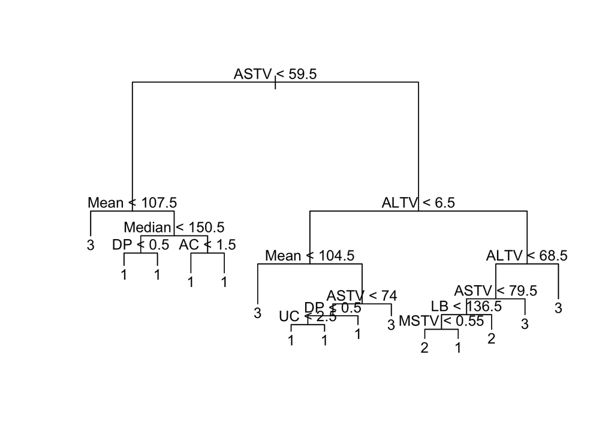

```r
plot(fit.tree)
text(fit.tree, pretty = 1)
```

```r
preds <- predict(fit.tree, newdata = test, type = "class")

# print confusion matrix
(confusion_matrix <- table(Predicted = preds, Actual = test$NSP))
```

```
##          Actual
## Predicted   1   2   3
##         1 279  18   3
##         2   2  37   1
##         3   4   2  30
```

```r
# Calculate accuracy/error rate
(accuracy <- sum(diag(confusion_matrix)) / sum(confusion_matrix))
```

```
## [1] 0.9202128
```

```r
(err_rate <- mean(preds != test$NSP))
```

```
## [1] 0.07978723
```

Here we can see a pretty good accuracy of about 92% from a decision tree with 15 terminal nodes. Below, I will investigate what happens if we grow this tree deeper and then prune it for predictions.

```r
set.seed(22)
# use tree.control() to make a larger tree
tree_ctrl <- tree.control(nobs = nrow(train), mincut = 1, minsize = 50, mindev = 0)

# create tree using controls defined above
tree.larger <- tree(NSP ~ ., data = train, control = tree_ctrl)
summary(tree.larger)
```

```
##
## Classification tree:
## tree(formula = NSP ~ ., data = train, control = tree_ctrl)
## Variables actually used in tree construction:
##  [1] "ASTV"     "Mean"     "Median"   "DP"       "Variance" "AC"
##  [7] "FM"       "ALTV"     "LB"       "Nmax"     "Max"      "UC"
## [13] "MSTV"
## Number of terminal nodes:  31
## Residual mean deviance:  0.269 = 462.4 / 1719
## Misclassification error rate: 0.05771 = 101 / 1750
```

```r
# prune tree using cross validation to find optimal size
(cv.larger = cv.tree(tree.larger, FUN = prune.misclass, K = 5))
```

```
## $size
##  [1] 31 21 16 15 14 10  9  8  5  4  3  1
##
## $dev
##  [1] 141 141 141 135 139 139 153 175 181 217 380 380
##
## $k
##  [1]  -Inf  0.00  0.40  2.00  3.00  3.75  9.00 10.00 12.00 37.00 54.00 55.50
##
## $method
## [1] "misclass"
##
## attr(,"class")
## [1] "prune"         "tree.sequence"
```

```r
k_vals <- c(seq(from = 4, to = 30, by = 2))
err_rates <- c()

for (i in seq_along(k_vals))
{
   k <- k_vals[i]
   prune.larger <- prune.misclass(tree.larger, best = k)
   preds <- predict(prune.larger, test, type = "class")
   err_rates[i] <- mean(preds != test$NSP)
}

# find best value of k
k_and_err <- data.frame(k = k_vals, Err = err_rates)
k_row <- which.min(k_and_err$Err)
(optimal_k <- k_and_err$k[k_row])
```

```
## [1] 22
```

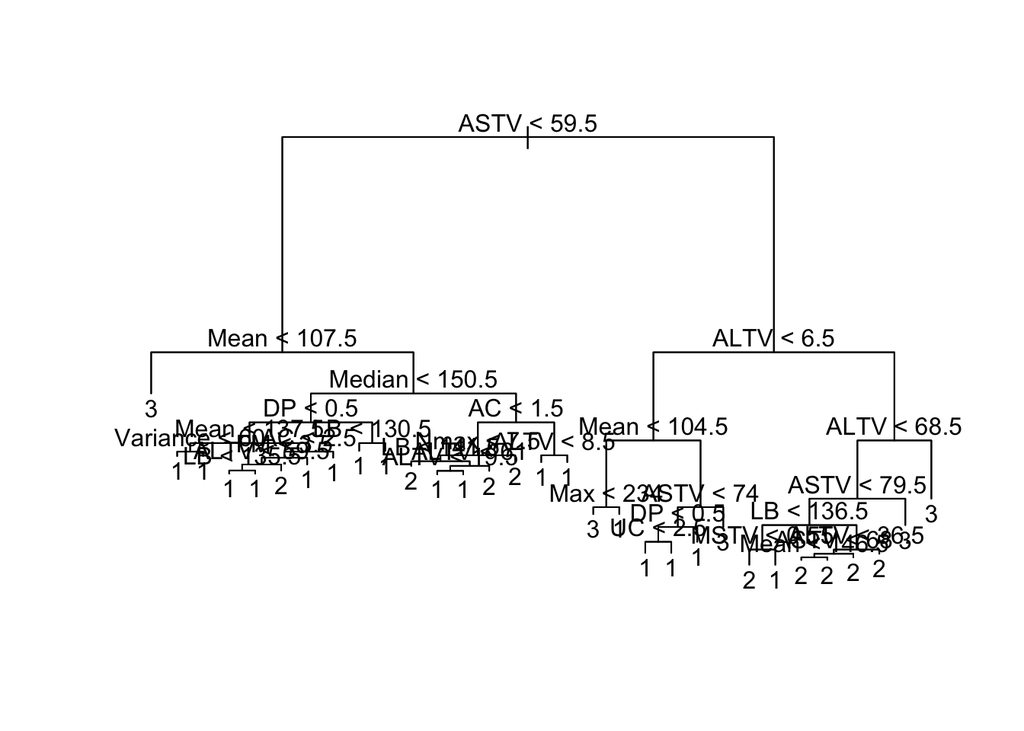

```r
tree.pruned <- prune.misclass(tree.larger, best = 22)
plot(tree.pruned)
text(tree.pruned, pretty = 1)
```

```r
preds_pruned <- predict(tree.pruned, test, type = "class")

confusion_matrix_pruned <- table(Predicted = preds_pruned, Actual = test$NSP)
(accuracy_pruned <- sum(diag(confusion_matrix_pruned)) / sum(confusion_matrix_pruned))
```

```
## [1] 0.9281915
```

```r
(err_rate <- mean(preds_pruned != test$NSP))
```

```
## [1] 0.07180851
```

When we make the tree deeper, we can see it starts with almost double the amount of terminal nodes as the original tree. After testing many values of k for the tree, we see that the best value (one that minimizes error) is 22. After creating a new decision tree using this parameter, we get a slightly improved accuracy rate of 92.8% compared to the original decision tree with 92%.

### Random Forest Model

```r
set.seed(22)
# create empty vector for oob errors
out_of_bag_errors <- c()

# loop through all values for mtry
for (mtry_values in 1:15)
   {
   # create each model and acces its error rate by looking at the oob row
    rf <- randomForest(NSP ~ ., data = train, mtry = mtry_values,
                          importance = TRUE)
    out_of_bag_errors[mtry_values] <- rf$err.rate[nrow(rf$err.rate), "OOB"]
}

# find min oob error and use as mtry value in rf model
out_of_bag_errors
```

```
##  [1] 0.09485714 0.06628571 0.05542857 0.05600000 0.05314286 0.05200000
##  [7] 0.05085714 0.05428571 0.05371429 0.05085714 0.05142857 0.05657143
## [13] 0.05257143 0.05257143 0.05542857
```

```r
(best <- which.min(out_of_bag_errors))
```

```
## [1] 7
```

```r
rf <- randomForest(NSP ~ ., data = train, mtry = best, importance = TRUE)

# predict values and find error rate
preds <- predict(rf, test)
(confusion_rf <- table(Predicted = preds, Actual = test$NSP))
```

```
##          Actual
## Predicted   1   2   3
##         1 281  12   0
##         2   3  45   1
##         3   1   0  33
```

```r
(accuracy_rf <- sum(diag(confusion_rf)) / sum(confusion_rf))
```

```
## [1] 0.9547872
```

```r
(err_rate <- mean(preds != test$NSP))
```

```
## [1] 0.04521277
```

### KNN Model

```r
set.seed(22)
# normalize data since it relies on distance - need same units
normalize <- function(x) {
  return ((x - min(x)) / (max(x) - min(x)))
}

train_pred <- normalize(train[1:21])
train_response <- train$NSP
test_pred <- normalize(test[1:21])
test_response <- test$NSP

# get predictions using knn method
accuracies <- c()
for (i in 1:10) {
   knn_pred <- knn(train_pred, test_pred, cl = train_response, k = i)
   # create table for confusion matrix
   confusion <- table(Pred = knn_pred, Actual = test_response)

   # print fraction of correct predictions
   accuracies[i] <- sum(diag(confusion)) / sum(confusion)
}

accuracies
```

```
##  [1] 0.7686170 0.7686170 0.7845745 0.7712766 0.7792553 0.7819149 0.7765957
##  [8] 0.7739362 0.7765957 0.7819149
```

```r
(best_k <- (which.max(accuracies)))
```

```
## [1] 3
```

```r
accuracies[best_k]
```

```
## [1] 0.7845745
```

Above we can see that KNN using the full set of predictors is easily the worst performing model we have seen so far, with an accuracy of under 80%. This does not surprise me as KNN is heavily affected by high dimensionality and we have 21 predictors.

### SVM Model

```r
set.seed(22)
# create svm with different costs - also testing different kernels and leaving best
tune.out = tune(svm, NSP ~ ., data = train, kernel = "radial",
                ranges = list(cost = c(.1,1,5,10,25,35,50,75,100)))
summary(tune.out)
```

```
##
## Parameter tuning of 'svm':
##
## - sampling method: 10-fold cross validation
##
## - best parameters:
##  cost
##    50
##
## - best performance: 0.06914286
##
## - Detailed performance results:
##    cost      error dispersion
## 1   0.1 0.14114286 0.01787840
## 2   1.0 0.08800000 0.01620727
## 3   5.0 0.07771429 0.01455617
## 4  10.0 0.07200000 0.01575320
## 5  25.0 0.07314286 0.01975818
## 6  35.0 0.07257143 0.02222132
## 7  50.0 0.06914286 0.02005887
## 8  75.0 0.06971429 0.01938744
## 9 100.0 0.07142857 0.02175935
```

```r
fit.svm = svm(NSP ~ ., data = train, kernel = "radial", cost = 50, scale = TRUE)
summary(fit.svm)
```

```
##
## Call:
## svm(formula = NSP ~ ., data = train, kernel = "radial", cost = 50,
##     scale = TRUE)
##
##
## Parameters:
##    SVM-Type:  C-classification
##  SVM-Kernel:  radial
##        cost:  50
##
## Number of Support Vectors:  395
##
##  ( 182 72 141 )
##
##
## Number of Classes:  3
##
## Levels:
##  1 2 3
```

```r
preds <- predict(fit.svm, newdata = test)
# print confusion matrix
(confusion_matrix <- table(Predicted = preds, Actual = test$NSP))
```

```
##          Actual
## Predicted   1   2   3
##         1 277  15   1
##         2   6  42   1
##         3   2   0  32
```

```r
# Calculate accuracy
(accuracy <- sum(diag(confusion_matrix)) / sum(confusion_matrix))
```

```
## [1] 0.9335106
```

In the code above, I tested SVMs with several different cost values to find which would give the lowest error and found that a cost around 50 worked the best. Additionally, I checked all of the different SVM kernels (linear, polynomial, radial, and sigmoid) and radial worked the best followed by polynomial. After creating a new SVM model based on these findings, the model had about 93.4% accuracy, which is solid compared to the rest of the models.

### PCA Models

In this section, I will perform Principal Component Analysis (PCA) on the data to reduce the dimensionality of the data we are using. This is because many times, the curse of high dimensionality can hinder certain models/algorithms from performing at their best due to considering noise or highly correlated variables that will throw off the model’s predictions. Overall, I will recreate the multinomial regression model, KNN model, and SVM model using the PCA data and compare their performance to the original models. I am expecting PCA to have the biggest impact on KNN because high dimensionality can drastically hurt KNN’s predictions. Additionally, I am not performing PCA for the decision tree and random forest models because trees already somewhat perform their own dimension reduction by choosing what splits are most important among all features.

```r
pca_data <- prcomp(ctg[1:21], center = TRUE, scale. = TRUE)
summary(pca_data)
```

```
## Importance of components:
##                          PC1    PC2     PC3     PC4     PC5     PC6     PC7
## Standard deviation     2.455 1.8663 1.35305 1.21991 1.07727 1.01887 0.97654
## Proportion of Variance 0.287 0.1659 0.08718 0.07087 0.05526 0.04943 0.04541
## Cumulative Proportion  0.287 0.4528 0.54001 0.61088 0.66614 0.71557 0.76098
##                           PC8     PC9    PC10    PC11    PC12    PC13    PC14
## Standard deviation     0.9335 0.86887 0.81740 0.78234 0.70530 0.63752 0.58053
## Proportion of Variance 0.0415 0.03595 0.03182 0.02915 0.02369 0.01935 0.01605
## Cumulative Proportion  0.8025 0.83843 0.87025 0.89939 0.92308 0.94244 0.95848
##                           PC15    PC16    PC17    PC18    PC19    PC20
## Standard deviation     0.53062 0.49231 0.38160 0.35551 0.22239 0.16266
## Proportion of Variance 0.01341 0.01154 0.00693 0.00602 0.00236 0.00126
## Cumulative Proportion  0.97189 0.98343 0.99037 0.99639 0.99874 1.00000
##                             PC21
## Standard deviation     1.545e-15
## Proportion of Variance 0.000e+00
## Cumulative Proportion  1.000e+00
```

```r
pca_components <- pca_data$x[, 1:10]
pca_components <- data.frame(pca_components)
```

From the PCA summary above, I will use the first 10 components of PCA because it captures over 85% of the variance, which I have found to be a good threshold based on brief research. Below I will recreate the multinomial regression and KNN models using the PCA data.

### Multinomial Regression Model using PCA

```r
set.seed(22)
trainIndex.pca <- sample(c(1:nrow(pca_components)), 1750)

train.pca <- pca_components[trainIndex.pca, ]
train.pca$NSP <- train$NSP
test.pca <- pca_components[-trainIndex.pca, ]
test.pca$NSP <- test$NSP

# multinomial
fit.multi.pca = multinom(NSP ~ ., data = train.pca)
summary(fit.multi.pca)
```

```
## Call:
## multinom(formula = NSP ~ ., data = train.pca)
##
## Coefficients:
##   (Intercept)        PC1      PC2      PC3      PC4        PC5        PC6
## 2    -3.55456  0.5572216 0.235239 1.200891 1.553463 -1.3592215 -0.6451231
## 3   -10.01439 -0.3868667 2.797787 3.856876 4.656035  0.1039342  4.5202812
##         PC7       PC8        PC9        PC10
## 2 -1.683421 0.1701398 -0.8011679 -0.18050663
## 3  3.542387 2.8448135 -2.5058289 -0.08376649
##
## Std. Errors:
##   (Intercept)        PC1       PC2       PC3       PC4       PC5       PC6
## 2   0.2125130 0.08413451 0.1127224 0.1461400 0.1539744 0.2811158 0.5612136
## 3   0.8860026 0.11524052 0.3151625 0.3661012 0.4713405 0.3561920 0.8662854
##         PC7       PC8       PC9      PC10
## 2 0.7531771 0.2031250 0.1434073 0.1369790
## 3 1.0272029 0.4758731 0.3755832 0.2550146
##
## Residual Deviance: 879.1817
## AIC: 923.1817
```

```r
preds <- predict(fit.multi.pca, newdata = test.pca)
# print confusion matrix
(confusion_matrix <- table(Predicted = preds, Actual = test.pca$NSP))
```

```
##          Actual
## Predicted   1   2   3
##         1 275  21   3
##         2   8  33   3
##         3   2   3  28
```

```r
# Calculate accuracy
(accuracy <- sum(diag(confusion_matrix)) / sum(confusion_matrix))
```

```
## [1] 0.893617
```

Note here that the accuracy for the multinomial regression model using PCA for dimension reduction is slightly better than the original model as well as the model that eliminated some features using backwards elimination. This is likely due to PCA combining some of the highly correlated features into individual components.

### KNN Model using PCA

```r
set.seed(22)

train.pca_pred <- normalize(train.pca[1:10])
train.pca_response <- train.pca$NSP
test.pca_pred <- normalize(test.pca[1:10])
test.pca_response <- test.pca$NSP

# get predictions using knn method
accuracies <- c()
for (i in 1:10) {
   knn.pca_pred <- knn(train.pca_pred, test.pca_pred, cl = train.pca_response, k = i)
   # create table for confusion matrix
   confusion <- table(Pred = knn.pca_pred, Actual = test.pca_response)

   # print fraction of correct predictions
   accuracies[i] <- sum(diag(confusion)) / sum(confusion)
}

accuracies
```

```
##  [1] 0.8750000 0.8829787 0.8989362 0.8829787 0.8989362 0.9042553 0.9122340
##  [8] 0.9042553 0.9042553 0.9122340
```

```r
(best_k <- (which.max(accuracies)))
```

```
## [1] 7
```

```r
accuracies[best_k]
```

```
## [1] 0.912234
```

Here we can see that KNN benefits greatly from dimension reduction using PCA, as the best KNN model here has about 13% higher accuracy than the original best KNN model, putting it back on par with the other models. This follows suit with my prediction above, as random points in high dimensional space tend to be similar distances from each other, therefore negatively impacting predictions. However, reducing the number of dimensions can help the KNN algorithm perform much better.

### SVM Model using PCA

```r
set.seed(22)
# create svm with different costs - also testing different kernels and leaving best
tune.out = tune(svm, NSP ~ ., data = train.pca, kernel = "radial",
                ranges = list(cost = c(.1,1,5,10,25,35,50,75,100)))
summary(tune.out)
```

[output not shown]

```r
fit.svm.pca = svm(NSP ~ ., data = train.pca, kernel = "radial", cost = 25, scale = TRUE)
summary(fit.svm.pca)
```

```
##
## Call:
## svm(formula = NSP ~ ., data = train.pca, kernel = "radial", cost = 25,
##     scale = TRUE)
##
##
## Parameters:
##    SVM-Type:  C-classification
##  SVM-Kernel:  radial
##        cost:  25
##
## Number of Support Vectors:  451
##
##  ( 209 74 168 )
##
##
## Number of Classes:  3
##
## Levels:
##  1 2 3
```

```r
preds <- predict(fit.svm.pca, newdata = test.pca)
# print confusion matrix
(confusion_matrix <- table(Predicted = preds, Actual = test.pca$NSP))
```

```
##          Actual
## Predicted   1   2   3
##         1 277  17   2
##         2   7  38   4
##         3   1   2  28
```

```r
# Calculate accuracy
(accuracy <- sum(diag(confusion_matrix)) / sum(confusion_matrix))
```

```
## [1] 0.912234
```

Here we can see that using PCA on SVM actually reduces it’s effectiveness by making it about 2% less accurate for this dataset. In this case, it is possible that PCA oversimplified the data, making it harder for the SVM to find a good decision boundary.

## Conclusion

Overall, we can see that the random forest model worked the best out of any of the models, with an accuracy of about 95.5% when classifying NSP. This did not particularly surprise me as random forests are typically quite accurate and rather flexible when it comes to handling complex non-linear situations with higher dimensionality. We were also able to see how dimension reductionality techniques like PCA are able to improve different models such as the multinomial regression models and (especially) the KNN model. Overall, I am quite happy with my results as I was hoping for at least 90% accuracy and was able to achieve over 95% with my top-performing model. However, I think I could potentially improve my results in the future by spending a little bit more time to better understand the dataset and the meaning of the individual predictors. I think having a greater understanding of the topic itself would help me enhance my analysis and models by providing me with greater context that I can use to form hypotheses prior to building models.